# DATA 606 Data Project: Causes of Financial Wellbeing

[figure not shown]

```r
# econ_inc_volatility
ggplot(data = cfpb_results) +
  geom_boxplot(mapping = aes(x=.residual, y=econ_inc_volatility, color=econ_inc_volatility)) +
  labs (title = "econ_inc_volatility")
```

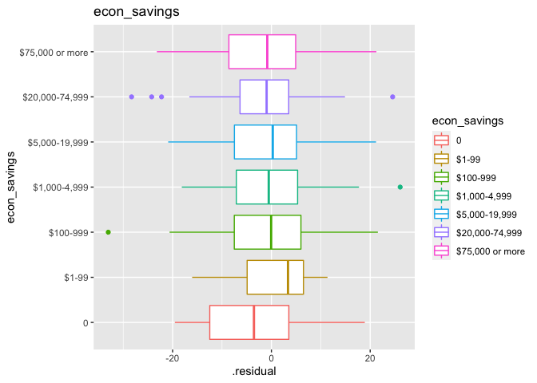

```r
# econ_savings
ggplot(data = cfpb_results) +
  geom_boxplot(mapping = aes(x=.residual, y=econ_savings, color=econ_savings)) +
  labs (title = "econ_savings")
```

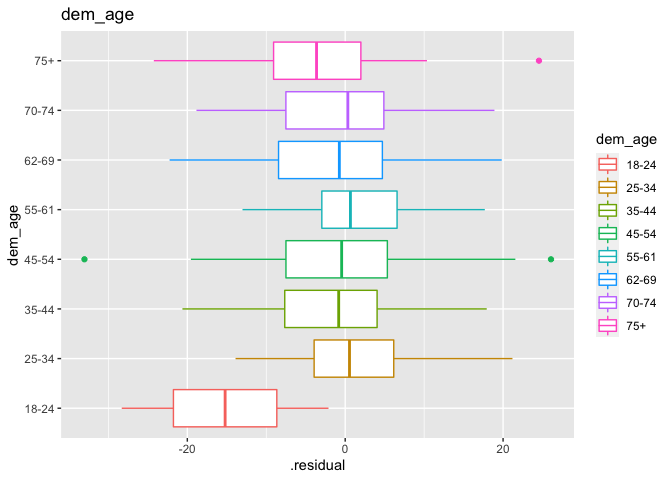

```r
# dem_age
ggplot(data = cfpb_results) +
  geom_boxplot(mapping = aes(x=.residual, y=dem_age, color=dem_age)) +
  labs (title = "dem_age")
```

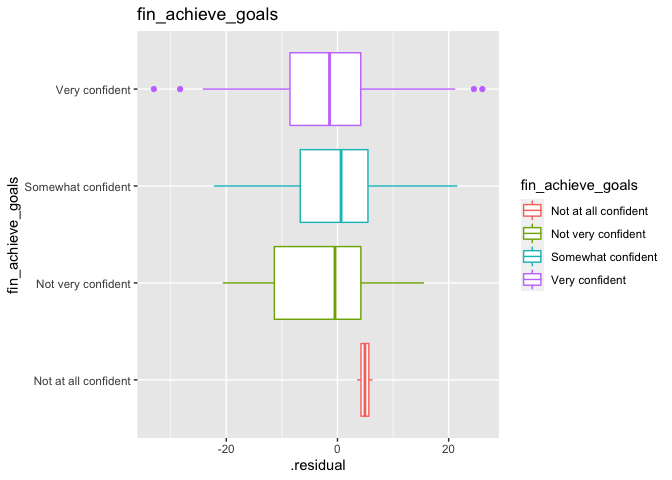

```r
# fin_achieve_goals
ggplot(data = cfpb_results) +
  geom_boxplot(mapping = aes(x=.residual, y=fin_achieve_goals, color=fin_achieve_goals)) +
  labs (title = "fin_achieve_goals")
```

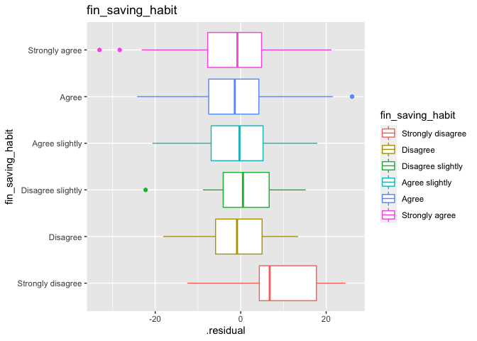

```r
# fin_saving_habit
ggplot(data = cfpb_results) +
  geom_boxplot(mapping = aes(x=.residual, y=fin_saving_habit, color=fin_saving_habit)) +
  labs (title = "fin_saving_habit")
```

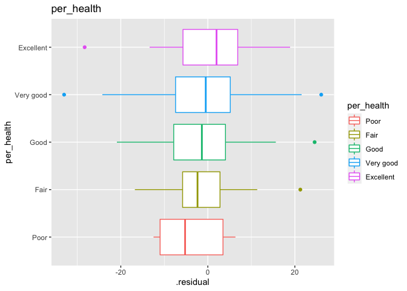

```r
# per_health
ggplot(data = cfpb_results) +
  geom_boxplot(mapping = aes(x=.residual, y=per_health, color=per_health)) +
  labs (title = "per_health")
```

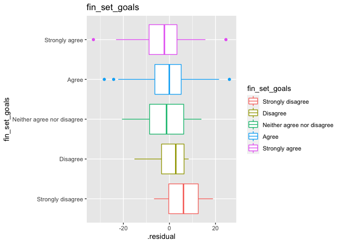

```r
# fin_set_goals
ggplot(data = cfpb_results) +
  geom_boxplot(mapping = aes(x=.residual, y=fin_set_goals, color=fin_set_goals)) +
  labs (title = "fin_set_goals")
```

# Part 5 - Conclusion

A linear regression model was developed using the results of the Consumer Financial Protection Bureau’s (CFPB) National Financial Well-Being Survey Public Use File (PUF). The model predicts over 0.5608 cfpb score given the 8 variable selected for the optimized model.

**Model Performance** - adjusted $R^2$ 0.5608655  
- root mean square error 9.609951

**Model Variables** The following variable are included in the model as significant contributors to the overall model accuracy.

- econ_hh_income (PPINCIMP) - The survey respondents Household Income for a given year.
- econ_savings (SAVINGSRANGES) - An assessment of the amount of savings that the survey respondant currenlty has.
- per_health (HEALTH) - An assessment of the survey respondents overall health.
- dem_age (agecat) - The age of the survey respondent (8 categories).
- fin_achieve_goals (GOALCONF) - An assessment of the ability of the survey respondent to achieve their financial goals.
- fin_saving_habit (SAVEHABIT) - An assessment of savings habits and how often money is put away.
- fin_consult_budget (PROPPLAN_1) - An assessment of how budgeting impacts spending decisions.
- fin_set_goals (PROPPLAN_3) - An assessment of financial planning and goal setting discipline.

The findings for the analysis are not surprising and are consistent with several studies in the industry however deeper analysis is warranted. The cfpb scaled score is designed to cover the entire population however it is not surprising that the resulting model breaks down slightly at the higher and lower ranges of the cfpb score. A more localized analysis of cfpb score ranges might provide some additional insight into the factors that impact consumer financial wellness.

# References

- Consumer Financial Protection Bureau - Financial Wellness Survey [*Financial well-being data*](https://www.consumerfinance.gov/data-research/financial-well-being-survey-data/) The PUF survey results can be accessed as a csv file [*Financial well-being survey data*](https://www.consumerfinance.gov/documents/5614/NFWBS_PUF_2016_data.csv)

# Appendix (optional)

## CFPB Financial Well-Being Scale Methodology

The CFPB Financial Well-Being Scale methodology uses the following 10 questions to calculate the cfpb score. There is some overlap between the questions used to calculate the cfpb score and the survey questions. The optimized models presented in this analysis did not include any of the variable that overlap with the scoring questions.

How well does this statement describe you or your situation?

1. I could handle a major unexpected expense
2. I am securing my financial future
3. Because of my money situation, I feel like I will never have the things I want in life*
4. I can enjoy life because of the way I’m managing my money
5. I am just getting by financially*
6. I am concerned that the money I have or will save won’t last*

How often does this statement apply to you?

7. Giving a gift for a wedding, birthday or other occasion would put a strain on my finances for the month*
8. I have money left over at the end of the month
9. I am behind with my finances*
10. My finances control my life*

## Review of the variables

The PUF includes financial attitude that were not included as part of the analysis but provide a interesting window into the relationship of financial attitudes to consumer financial wellbeing.

```r
result_df <- getResultsCFPBFile()
```

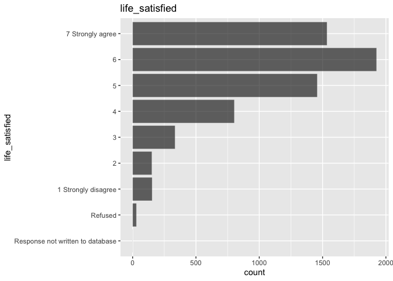

```r
# life_satisfied
ggplot(result_df, aes(x=life_satisfied)) +
  geom_bar(color="white", fill="black", alpha = 0.6, size = 0.1) +
  coord_flip() +
  labs(title = "life_satisfied")
```

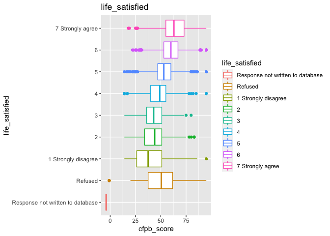

```r
ggplot(data = result_df) +
  geom_boxplot(mapping = aes(x=cfpb_score, y=life_satisfied, color=life_satisfied)) +
  labs (title = "life_satisfied")
```

[figure not shown]

```r
ggplot(result_df,
    aes(cfpb_score, fill = life_satisfied, y = stat(density))) +
    geom_histogram(binwidth = 1, alpha = 0.7, bins = 100, color="white",size = 0.1) +
    geom_vline(aes(xintercept = mean(cfpb_score)), linetype = "dashed", size = 0.2) +
    scale_fill_brewer(palette="Spectral") +
    labs(title = "CFPB Score (by life_satisfied)")
```

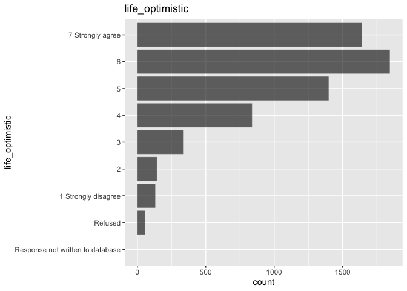

```r
# life_optimistic
ggplot(result_df, aes(x=life_optimistic)) +
  geom_bar(color="white", fill="black", alpha = 0.6, size = 0.1) +
  coord_flip() +
  labs(title = "life_optimistic")
```

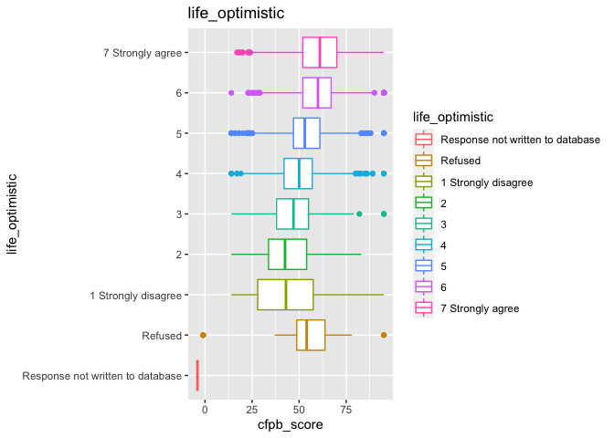

```r
ggplot(data = result_df) +
  geom_boxplot(mapping = aes(x=cfpb_score, y=life_optimistic, color=life_optimistic)) +
  labs (title = "life_optimistic")
```

[figure not shown]

```r
ggplot(result_df,
    aes(cfpb_score, fill = life_optimistic, y = stat(density))) +
    geom_histogram(binwidth = 1, alpha = 0.7, bins = 100, color="white",size = 0.1) +
    geom_vline(aes(xintercept = mean(cfpb_score)), linetype = "dashed", size = 0.2) +
    scale_fill_brewer(palette="Spectral") +
    labs(title = "CFPB Score (by life_optimistic)")
```

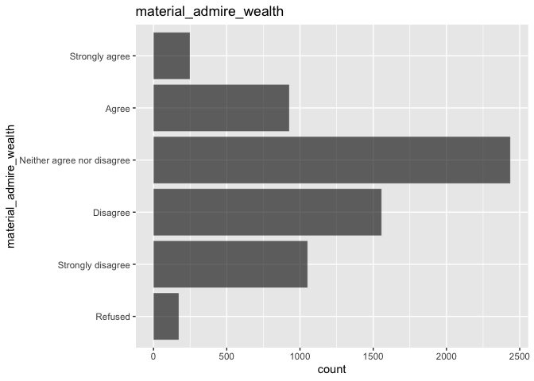

```r
# material_admire_wealth
ggplot(result_df, aes(x=material_admire_wealth)) +
  geom_bar(color="white", fill="black", alpha = 0.6, size = 0.1) +
  coord_flip() +
  labs(title = "material_admire_wealth")
```

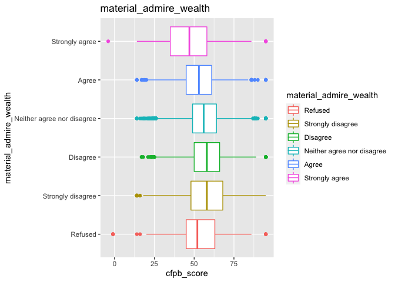

```r
ggplot(data = result_df) +
  geom_boxplot(mapping = aes(x=cfpb_score, y=material_admire_wealth, color=material_admire_wealth)) +
  labs (title = "material_admire_wealth")
```

[figure not shown]

```r
ggplot(result_df,
    aes(cfpb_score, fill = material_admire_wealth, y = stat(density))) +
    geom_histogram(binwidth = 1, alpha = 0.7, bins = 100, color="white",size = 0.1) +
    geom_vline(aes(xintercept = mean(cfpb_score)), linetype = "dashed", size = 0.2) +
    scale_fill_brewer(palette="Spectral") +
    labs(title = "CFPB Score (by material_admire_wealth)")
```

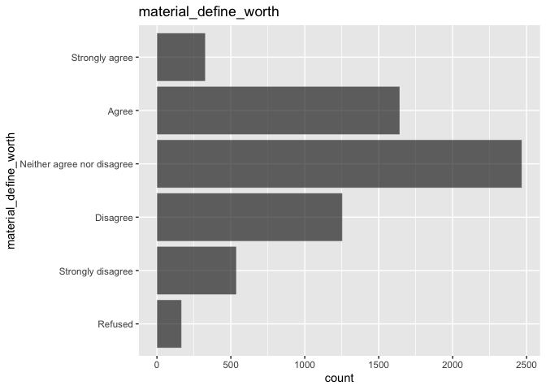

```r
# material_define_worth
ggplot(result_df, aes(x=material_define_worth)) +
  geom_bar(color="white", fill="black", alpha = 0.6, size = 0.1) +
  coord_flip() +
  labs(title = "material_define_worth")
```

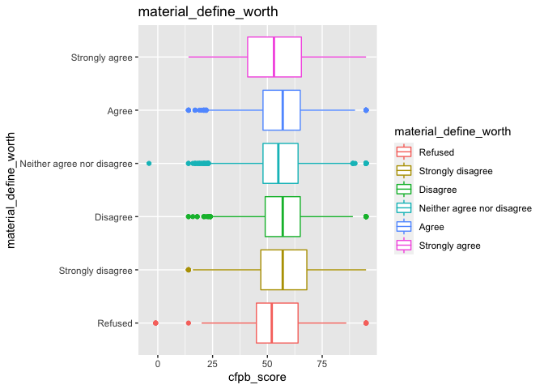

```r
ggplot(data = result_df) +
  geom_boxplot(mapping = aes(x=cfpb_score, y=material_define_worth, color=material_define_worth)) +
  labs (title = "material_define_worth")
```

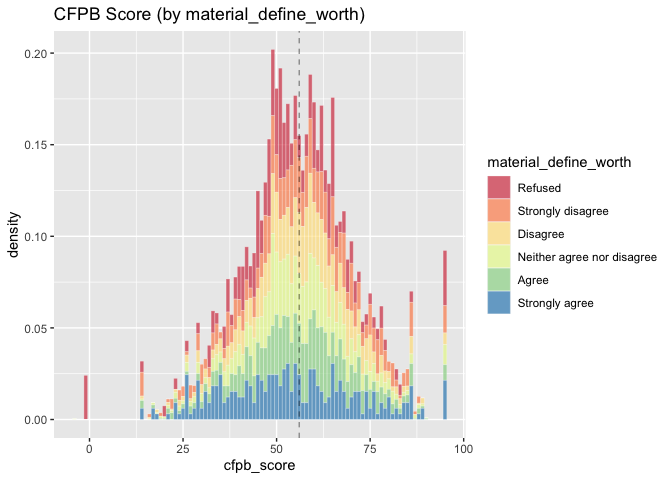

```r
ggplot(result_df,
    aes(cfpb_score, fill = material_define_worth, y = stat(density))) +
    geom_histogram(binwidth = 1, alpha = 0.7, bins = 100, color="white",size = 0.1) +
    geom_vline(aes(xintercept = mean(cfpb_score)), linetype = "dashed", size = 0.2) +
    scale_fill_brewer(palette="Spectral") +
    labs(title = "CFPB Score (by material_define_worth)")
```

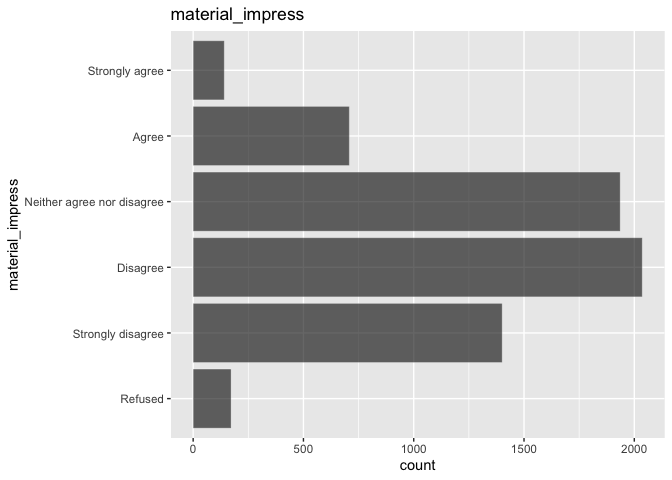

```r
# material_impress
ggplot(result_df, aes(x=material_impress)) +
  geom_bar(color="white", fill="black", alpha = 0.6, size = 0.1) +
  coord_flip() +
  labs(title = "material_impress")
```

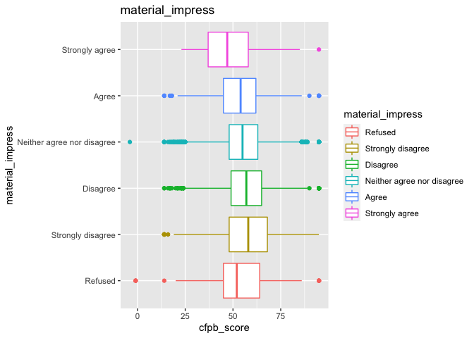

```r
ggplot(data = result_df) +
  geom_boxplot(mapping = aes(x=cfpb_score, y=material_impress, color=material_impress)) +
  labs (title = "material_impress")
```

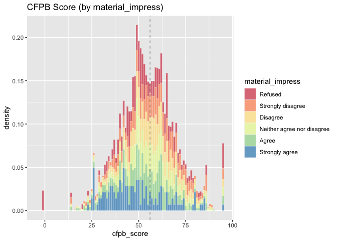

```r
ggplot(result_df,
    aes(cfpb_score, fill = material_impress, y = stat(density))) +
    geom_histogram(binwidth = 1, alpha = 0.7, bins = 100, color="white",size = 0.1) +
    geom_vline(aes(xintercept = mean(cfpb_score)), linetype = "dashed", size = 0.2) +
    scale_fill_brewer(palette="Spectral") +
    labs(title = "CFPB Score (by material_impress)")
```